# Data smells, data cleaning

Any time you are given a dataset from anyone, you should immediately be suspicious. Is this data what I think it is? Does it include what I expect? Is there anything I need to know about it? Will it produce the information I expect?

One of the first things you should do is give it the smell test.

Failure to give data the smell test [can lead you to miss stories and get your butt kicked on a competitive story](https://source.opennews.org/en-US/learning/handling-data-about-race-and-ethnicity/).

When you get data from someone else, you need to know what you have. The first way to know what you have is to look at descriptive statistics.

### Descriptives

The best way to understand this is with an example. For this one, we’re going to look at a favorite dataset of mine. The city of Lincoln, Nebraska surveys people who come into contact with the police. The three main groups of people they survey are people who were in car accidents, the victims of crime and people who were arrested. And they ask them questions like how would you rate the professionalism of the officer? How respected did the officer make you feel? It’s a fun dataset. But can we just bust it out and use it?

Descriptives will tell us.

First, let’s import a new library, called `psych` because it has a lot of tools for pyschological data analysis. We want it because it does descriptives very well.

```r
library(psych)
```

Now let’s import [the data](https://www.dropbox.com/s/imab0ly53wca56f/QSA_1996_2016.csv?dl=0).

```r
survey <- read.csv("../Data/QSA_1996_2016.csv")
```

And it couldn’t be easier to generate descriptives.

```r
describe(survey)
```

```
      vars     n     mean       sd  median  trimmed      mad min   max range
DATE*    1 78134  2905.02  1735.09  2809.0  2883.77  2268.38   1  6048  6047
RKY*     2 78134 22505.91 19136.86 20497.5 21338.15 27778.73   1 58012 58011
DVC*     3 78134     2.00     0.85     2.0     2.00     1.48   1     3     2
NATR*    4 78134    16.05    23.06     2.0    11.18     1.48   1    75    74
Q1*      5 78134     3.83     0.61     4.0     4.00     0.00   1     4     3
Q2*      6 78134     3.67     0.79     4.0     3.87     0.00   1     4     3
Q3*      7 78134     3.80     0.66     4.0     4.00     0.00   1     4     3
Q4*      8 78134     3.71     0.76     4.0     3.93     0.00   1     4     3
Q5*      9 78134     3.80     0.66     4.0     4.00     0.00   1     4     3
Q6*     10 78134     3.68     0.78     4.0     3.89     0.00   1     4     3
Q9*     11 78134     4.99     1.20     5.0     5.20     1.48   1     7     6
Q17*    12 78134     3.03     1.13     3.0     2.91     1.48   1     7     6
AGE     13 78134    34.98    16.03    31.0    33.25    14.83 -89    89   178
RACE*   14 78134    10.30     1.99    11.0    10.90     0.00   1    12    11
SEX*    15 78134     5.03     1.00     6.0     5.04     0.00   1     8     7
ZIP*    16 78134   724.59   218.55   778.0   775.21    66.72   1  1424  1423
FID     17 78134 39067.50 22555.49 39067.5 39067.50 28960.37   1 78134 78133
       skew kurtosis    se
DATE*  0.09    -1.25  6.21
RKY*   0.28    -1.31 68.46
DVC*   0.00    -1.61  0.00
NATR*  1.43     0.67  0.08
Q1*   -3.65    12.12  0.00
Q2*   -2.15     3.13  0.00
Q3*   -3.28     9.48  0.00
Q4*   -2.41     4.34  0.00
Q5*   -3.25     9.27  0.00
Q6*   -2.27     3.68  0.00
Q9*   -1.57     2.70  0.00
Q17*   0.88     0.96  0.00
AGE    0.43     3.10  0.06
RACE* -2.86     7.46  0.01
SEX*  -0.10    -1.85  0.00
ZIP*  -2.43     5.93  0.78
FID    0.00    -1.20 80.69
```

Okay, there’s a lot here, but let’s look closely. Some of them – the Q fields – are questions. And with the exception of Q9, they’re yes and no questions. But if you look at the minimum and maximum of those questions, you see the minumum is 1 and the max is either 4 or 7. So, R is attempting to describe these things mathematically when they aren’t numbers.

But look at age. There’s someone in the dataset who is -89? Uh oh. That’s not right. And if we’re calculating averages, that’s going to mess things up.

One thing we may also want to look at is the RACE field. But running decriptives on the whole dataset doesn’t tell us much. Thankfully, the `psych` library has a grouping method.

```r
describeBy(inmates, "RACE")
```

[output not shown]

[output cut: 311 more lines]

```
DVC*     3 1     2 NA      2       2   0     2     2     0   NA       NA NA
NATR*    4 1     2 NA      2       2   0     2     2     0   NA       NA NA
Q1*      5 1     4 NA      4       4   0     4     4     0   NA       NA NA
Q2*      6 1     4 NA      4       4   0     4     4     0   NA       NA NA
Q3*      7 1     4 NA      4       4   0     4     4     0   NA       NA NA
Q4*      8 1     4 NA      4       4   0     4     4     0   NA       NA NA
Q5*      9 1     4 NA      4       4   0     4     4     0   NA       NA NA
Q6*     10 1     4 NA      4       4   0     4     4     0   NA       NA NA
Q9*     11 1     6 NA      6       6   0     6     6     0   NA       NA NA
Q17*    12 1     2 NA      2       2   0     2     2     0   NA       NA NA
AGE     13 1    46 NA     46      46   0    46    46     0   NA       NA NA
RACE*   14 1    12 NA     12      12   0    12    12     0   NA       NA NA
SEX*    15 1     7 NA      7       7   0     7     7     0   NA       NA NA
ZIP*    16 1   823 NA    823     823   0   823   823     0   NA       NA NA
FID     17 1 75625 NA  75625   75625   0 75625 75625     0   NA       NA NA
```

Look primarily at n.

In other words, our race data is a bit of a mess. We have decisions to make – fix it? Or exclude those records?

### Histograms and barplots.

Another simple way to look at the data is through histograms and barplots.

Histograms need a numeric value. So for our data, age is a good one to look at. And right away, you’ll see the problem we found above.

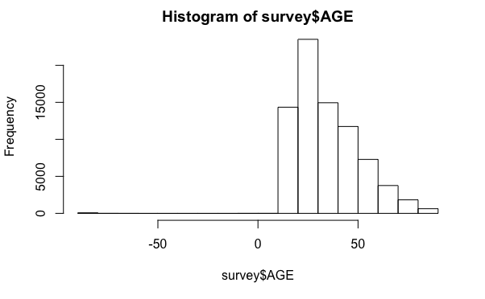

```r
hist(survey$AGE)
```

For things that aren’t numbers, we use barplots. And we have to summarize them – i.e. count them – so they can become a plot.

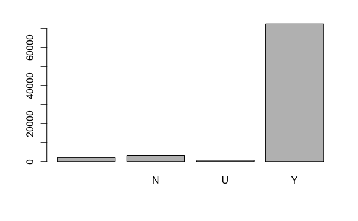

```r
barplot(summary(survey$Q1))
```

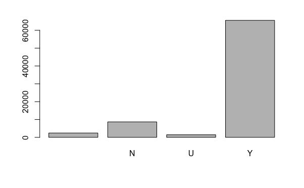

```r
barplot(summary(survey$Q2))
```

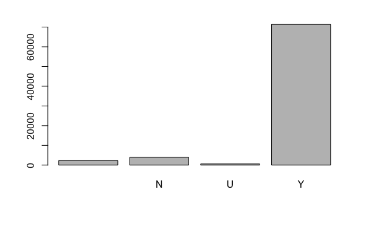

```r
barplot(summary(survey$Q3))
```

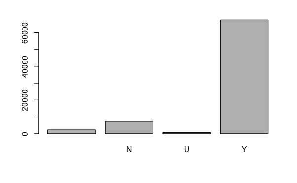

```r
barplot(summary(survey$Q4))
```

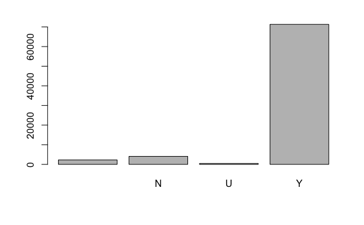

```r
barplot(summary(survey$Q5))
```

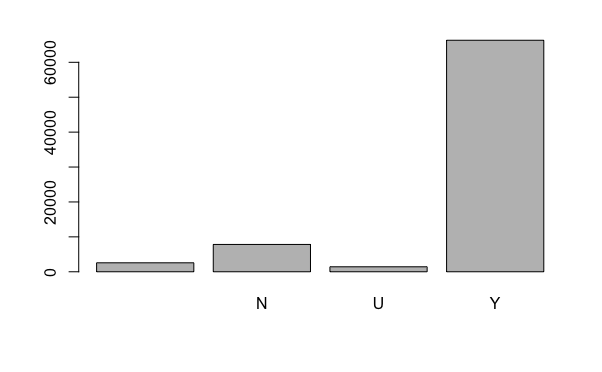

```r
barplot(summary(survey$Q6))
```

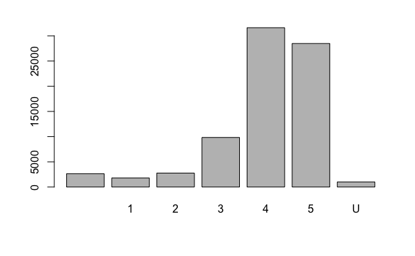

```r
barplot(summary(survey$Q9))
```

Note for each question, we have blanks and unknowns in addition to the yes and no answers we’d expect.